# Global Ecology Digest from May 18, 2026 to June 01, 2026

2026-06-01

[figure not shown]

Home · Archive

Science-only curated digest (publications, data, jobs) from the 🦋 [Bluesky Global Ecology feed](https://bsky.app/profile/did:plc:ppsghcl5bbpgjcljnhra353s/feed/global.ecology) 🌐. Not on BlueSky? Email us to receive updates. On BlueSky? DM [@global-ecology.bsky.social](https://bsky.app/profile/global-ecology.bsky.social) to contribute. [Like & pin the feed](https://bsky.app/profile/did:plc:ppsghcl5bbpgjcljnhra353s/feed/global.ecology). Starter packs: [Vol. 1](https://bsky.app/starter-pack/nmouquet.bsky.social/3lfum2bjpab24), [Vol. 2](https://bsky.app/starter-pack/nmouquet.bsky.social/3ld2m2csaai2x), [Vol. 3](https://go.bsky.app/MkLHiKU), [Vol. 4](https://go.bsky.app/Dsk4TQ3).

# Digest from May 18, 2026 to June 01, 2026

**59 posts curated.**

Several tools and datasets support the fortnight’s work. The Brazilian Tadpoles database migrates to a public site with interactive phylogeny. GeoLibre expands geospatial format support for lightweight GIS. The Spatial+ package addresses spatial confounding in ecological models. Counterfactual methods for evaluating conservation interventions are compared. Precision ecology frames context-sensitive evidence transfer. The hespdiv package automates hierarchical bioregionalisation in R. Frescalo scaling guides species trend detection from unstructured data. Timber tracing accuracy improves by combining chemical data across tree genera. BIEN 4.2 provides a reproducible standard for plant biodiversity data. A GBIF sampling-effort dataset supports bias-aware species distribution models.

Community news spans jobs, events, and resources. A Retaria collaboration marks a new multi-lab foraminifera paper. A large-herbivore postdoc at Aarhus University focuses on rewilding and alien ungulates. The Digest v2 launches with weekly wrap-ups and improved visualisation. An eco-evolutionary seminar features Korinna Allhoff. A GuardIAS webinar on biological invasion response is now on YouTube. A Greenland postdoc seeks expertise in vegetation mapping and herbivory. The starter pack Vol. 3 is complete and Vol. 4 is open for entries. An Atlas of Botany discussion and signing takes place at Royal Botanic Garden Edinburgh on June 11th.

Many thanks to all who contribute to the Global Ecology feed by sharing their science on Bluesky.

##### 📄 Brazilian Tadpoles 5.0 — Banco de dados de girinos do Brasil

Shared by **Diogo B Proietti** [@provete.bsky.social](https://bsky.app/profile/provete.bsky.social) · 2026-05-31 · 💚 3 likes on Bluesky

[output not shown]

**link:** https://diogoprov.github.io/Brazilian-Tadpoles-5.0  
[View Original Post on Bluesky](https://bsky.app/profile/did:plc:x35kvbbfjlu7xsh5qvoamif7/post/3mn6p6bcjnc2k)↑ Up

[output not shown]

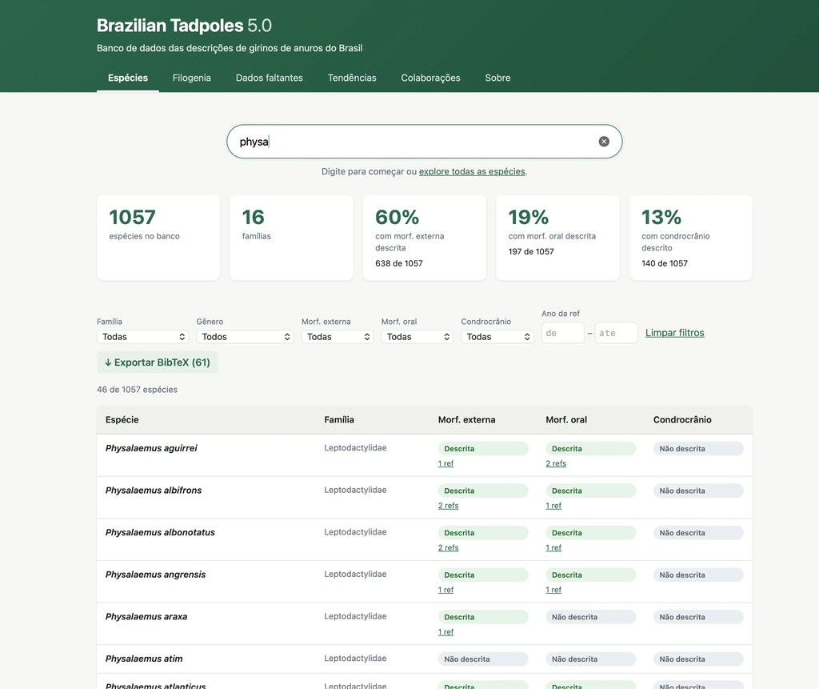

##### 📄 Global peatland carbon pool sizes: estimates, uncertainties, and future research directions ✨ AI title

Shared by **Global Change Biology** [@globalchangebio.bsky.social](https://bsky.app/profile/globalchangebio.bsky.social) · 2026-05-30 · 💚 6 likes on Bluesky

```
<div class='tag-row'><span class='tag tag-climate'>climate</span><span class='tag tag-biogeochemistry'>biogeochemistry</span></div>
{% raw %}REVIEW Global Peatland Carbon Pool Sizes: Current Estimates, Uncertainties, and Future Research Directions 🔗 buff.ly/s1chid5{% endraw %}
```

**link:** https://buff.ly/s1chid5  
[View Original Post on Bluesky](https://bsky.app/profile/did:plc:md4v5ohqbghb7ncvj57i6nhz/post/3mn474o7jq32p)↑ Up

[output not shown]

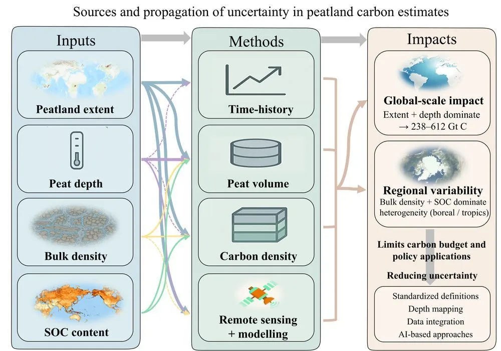

##### 📄 When does AI-driven management cause unintended ecological consequences ✨ AI title

Shared by **Pablo Garcia-Diaz** [@pablo-ecology.bsky.social](https://bsky.app/profile/pablo-ecology.bsky.social) · 2026-05-30 · 💚 4 likes on Bluesky

```
<div class='tag-row'><span class='tag tag-policy'>policy</span></div>
{% raw %}When does management using artificial intelligence lead to unintended consequences? A case study using ‘smart’ traps 🌎🌐🧪{% endraw %}
```

**link:** https://www.sciencedirect.com/science/article/pii/S030438002600102X  
[View Original Post on Bluesky](https://bsky.app/profile/did:plc:jvl2oy4s2hpizxkbd7ngq7ty/post/3mn45bx4oq22k)↑ Up

[output not shown]

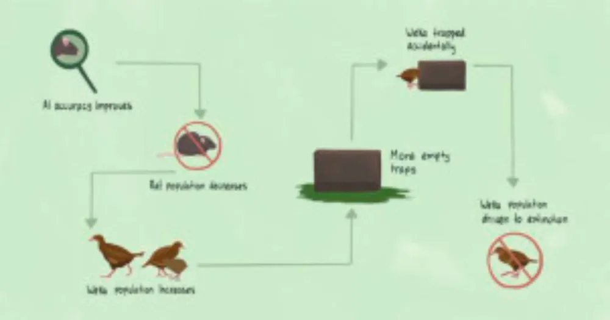

Shared by **Qiusheng Wu** [@giswqs.bsky.social](https://bsky.app/profile/giswqs.bsky.social) · 2026-05-30 · 💚 18 likes on Bluesky

```
<div class='tag-row'><span class='tag tag-methods'>methods</span></div>
{% raw %}GeoLibre v0.5.0 is out! This update significantly expands data format support, making it easier to work with a wide range of geospatial datasets in a lightweight, modern GIS environment.{% endraw %}
```

[View Original Post on Bluesky](https://bsky.app/profile/did:plc:pnv3wsjrwnzsmeh7bu7o26g3/post/3mn3wgeyzjc2p)↑ Up

[output not shown]

[figure not shown]

##### 📄 Integrating viruses into global ocean ecosystem models with vDarwin ✨ AI title

Shared by **Joshua Weitz** [@joshuasweitz.bsky.social](https://bsky.app/profile/joshuasweitz.bsky.social) · 2026-05-29 · 💚 40 likes on Bluesky

```
<div class='tag-row'><span class='tag tag-microbiome'>microbiome</span><span class='tag tag-biogeochemistry'>biogeochemistry</span></div>
{% raw %}Viruses are highly abundant in the oceans, but there is one place you won't typically find them: in global ocean ecosystem until now. Introducing "vDarwin", an explicit integration of viruses into the MITgcm/Darwin global ecosystem framework: a 🧵{% endraw %}
```

**link:** https://www.biorxiv.org/content/10.64898/2026.05.27.728272v1  
[View Original Post on Bluesky](https://bsky.app/profile/did:plc:pdvoxeret2wq6tzu7gxy7eeh/post/3mmyrslqca227)↑ Up

[output not shown]

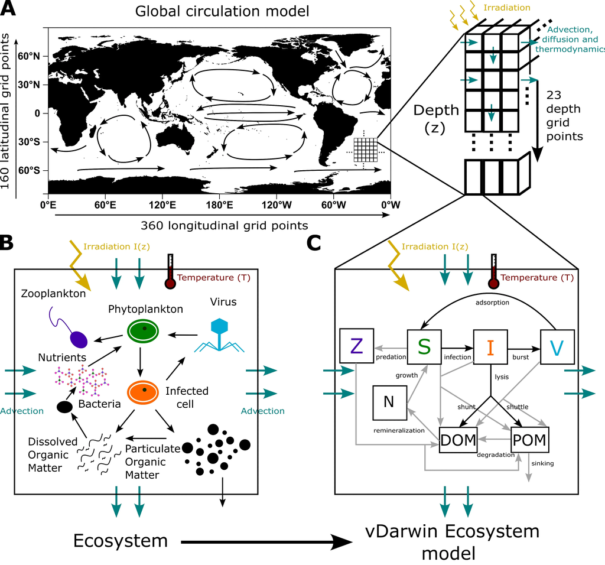

##### Post by Julie Meilland [@juliemeilland.bsky.social](https://bsky.app/profile/juliemeilland.bsky.social)

2026-05-29 · 💚 17 likes on Bluesky

```
<div class='tag-row'><span class='tag tag-microbiome'>microbiome</span></div>
{% raw %}We got our first common paper out theLifeOfRetaria with @sandinmm.bsky.social , @raphaelmorard.bsky.social, @nicolecoots.bsky.social, @mattgr3co.bsky.social, Nicolaas Glock and Natalia Llopis-Monferrer - first product of our seminar series! check it out!{% endraw %}
```

**link:** https://onlinelibrary.wiley.com/doi/abs/10.1002/bies.70148  
[View Original Post on Bluesky](https://bsky.app/profile/did:plc:3y6k6l6arivcay7y5c5p3yhr/post/3mmynidvnds26)↑ Up

[output not shown]

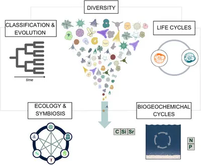

##### 📄 Invasive fishes and temperature jointly reshape community size structure across climatic zones ✨ AI title

Shared by **Global Change Biology** [@globalchangebio.bsky.social](https://bsky.app/profile/globalchangebio.bsky.social) · 2026-05-29 · 💚 5 likes on Bluesky

```
<div class='tag-row'><span class='tag tag-fish'>fish</span><span class='tag tag-climate'>climate</span><span class='tag tag-traits'>traits</span><span class='tag tag-macroecology'>macroecology</span></div>
{% raw %}Invasive Fishes Interact With Temperature to Reshape Community Size Structure Across Climatic Zones 🔗 buff.ly/8JV63e8{% endraw %}
```

**link:** https://buff.ly/8JV63e8  
[View Original Post on Bluesky](https://bsky.app/profile/did:plc:md4v5ohqbghb7ncvj57i6nhz/post/3mmyjrmldls2d)↑ Up

[output not shown]

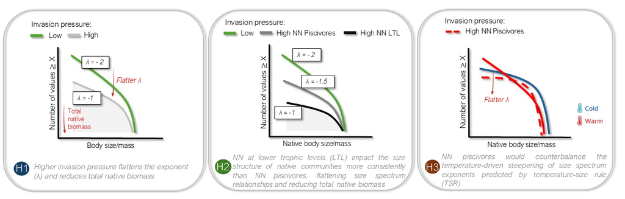

##### 📄 Satellite hindcasts reveal relaxation of foliar trait conservativeness in mountain grassland over four decades ✨ AI title

Shared by **Ecography** [@ecography.bsky.social](https://bsky.app/profile/ecography.bsky.social) · 2026-05-29 · 💚 4 likes on Bluesky

```
<div class='tag-row'><span class='tag tag-traits'>traits</span><span class='tag tag-climate'>climate</span></div>
{% raw %}Satellite hindcasts of foliar traits reveal a subtle but consistent relaxation of conservativeness in a biodiverse mountain grassland over the last four decades vist.ly/55v5w FunctionalTraits LeafEconomicsSpectrum{% endraw %}
```

**link:** https://vist.ly/55v5w  
[View Original Post on Bluesky](https://bsky.app/profile/did:plc:gzozs2g2etnvprbwjby4ujhu/post/3mmy7pk62ys2b)↑ Up

[output not shown]

[figure not shown]

##### 📄 Centuries of European research have documented only 37% of seed-dispersal interactions ✨ AI title

Shared by **Sara Mendes** [@sarammendes.bsky.social](https://bsky.app/profile/sarammendes.bsky.social) · 2026-05-29 · 💚 33 likes on Bluesky

```
<div class='tag-row'><span class='tag tag-birds'>birds</span><span class='tag tag-macroecology'>macroecology</span></div>
{% raw %}New paper out in New Phytologist 🌱 After centuries of research in Europe, we have studied only ~37% of all seed-dispersal interactions. Birds of prey, ants, and rodents are among the most understudied - yet researchers rarely flag them as gaps!{% endraw %}
```

**link:** https://nph.onlinelibrary.wiley.com/doi/10.1111/nph.71294  
[View Original Post on Bluesky](https://bsky.app/profile/did:plc:fewnf7uhguc2fuhiouz6rofx/post/3mmy2r6auws2d)↑ Up

[output not shown]

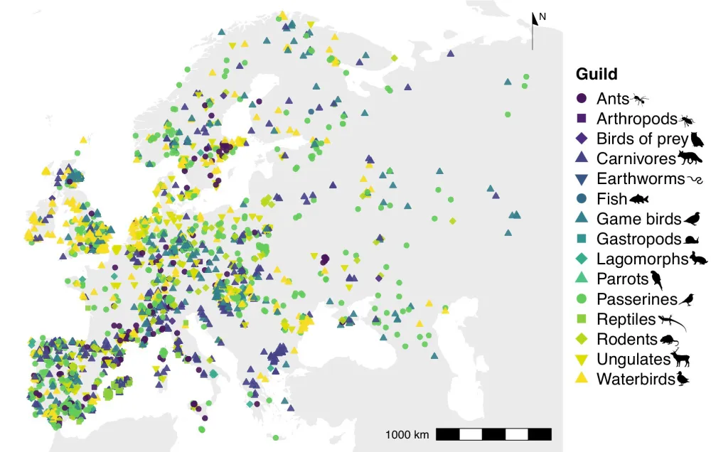

##### 📄 Cross-ecosystem linkages between freshwater insects and riparian birds across the USA

Shared by **Nature Ecology & Evolution** [@natecoevo.nature.com](https://bsky.app/profile/natecoevo.nature.com) · 2026-05-29 · 💚 17 likes on Bluesky

```
<div class='tag-row'><span class='tag tag-rivers-streams'>rivers-streams</span><span class='tag tag-freshwater'>freshwater</span><span class='tag tag-birds'>birds</span><span class='tag tag-macroecology'>macroecology</span></div>
{% raw %}ICYMI: Lage-scale analysis shows the importance of freshwater insects such as mayflies, stoneflies and caddisflies for riparian avian communities{% endraw %}
```

**link:** https://www.nature.com/articles/s41559-026-03041-1  
[View Original Post on Bluesky](https://bsky.app/profile/did:plc:vxpbqky6dsgs2vnedakzfusk/post/3mmy2f7jto227)↑ Up

[output not shown]

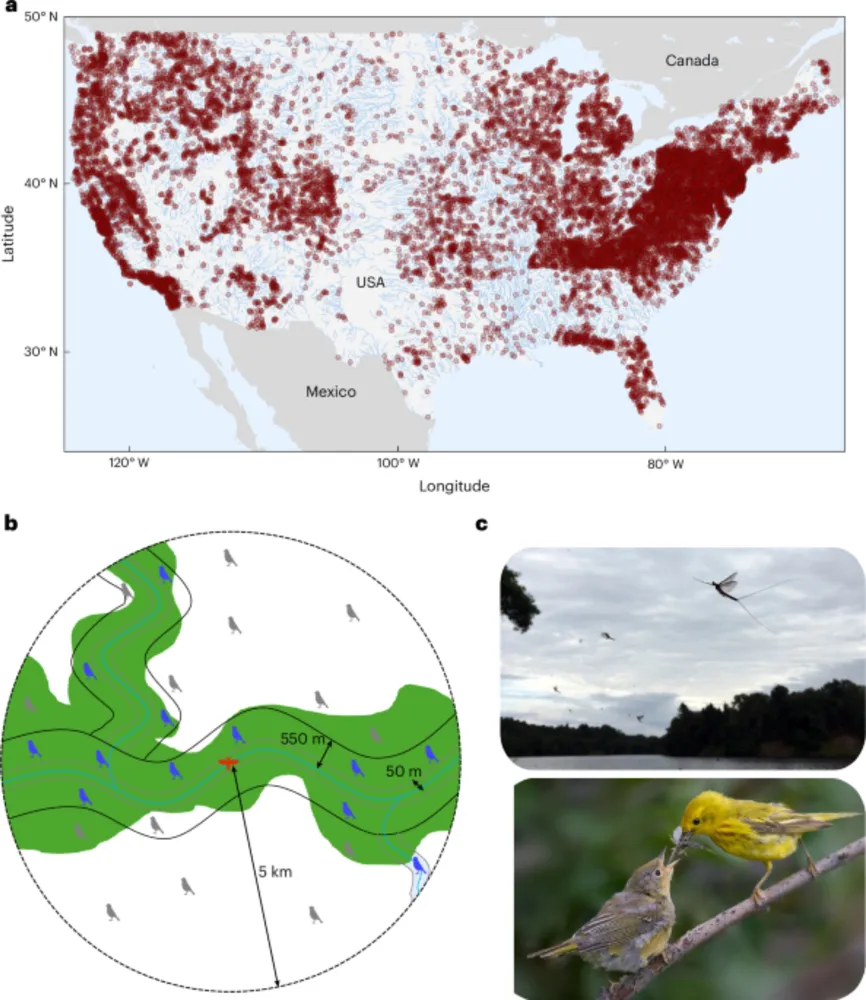

##### 📄 Biological invasions disrupt size spectrum and trophic interactions in freshwater fish communities ✨ AI title

Shared by **Journal of Animal Ecology** [@animalecology.bsky.social](https://bsky.app/profile/animalecology.bsky.social) · 2026-05-28 · 💚 17 likes on Bluesky

```
<div class='tag-row'><span class='tag tag-freshwater'>freshwater</span><span class='tag tag-fish'>fish</span><span class='tag tag-traits'>traits</span></div>
{% raw %}New research show biological invasions disrupt the relationship between size spectrum and trophic interactions in freshwater fish communities🌍 🐟️ 📈 🔎 Read more: buff.ly/9RvuSYJ{% endraw %}
```

**link:** https://buff.ly/9RvuSYJ  
[View Original Post on Bluesky](https://bsky.app/profile/did:plc:cvm6m4ardajaxaw57d6uqms4/post/3mmvjnzztx72p)↑ Up

[output not shown]

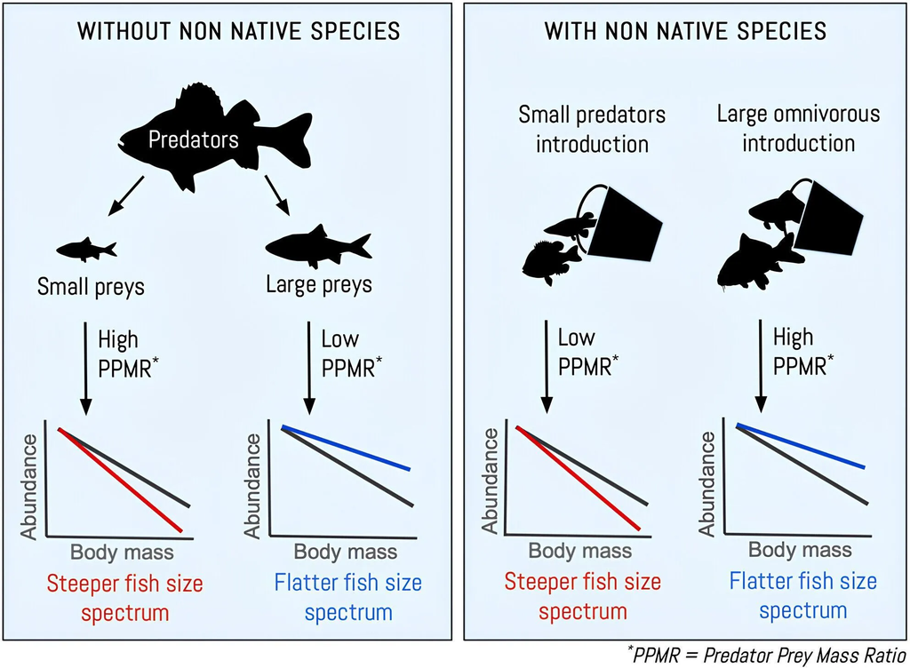

##### 📄 Postdoc position in large-herbivore ecology, trophic rewilding, and novel ecosystems ✨ AI title

Shared by **Jens-Christian Svenning** [@jcsvenning.bsky.social](https://bsky.app/profile/jcsvenning.bsky.social) · 2026-05-28 · 💚 24 likes on Bluesky

[output not shown]

[View Original Post on Bluesky](https://bsky.app/profile/did:plc:vo4aavnlpxx554hsl534zi3a/post/3mmvdf372wk23)↑ Up

[output not shown]

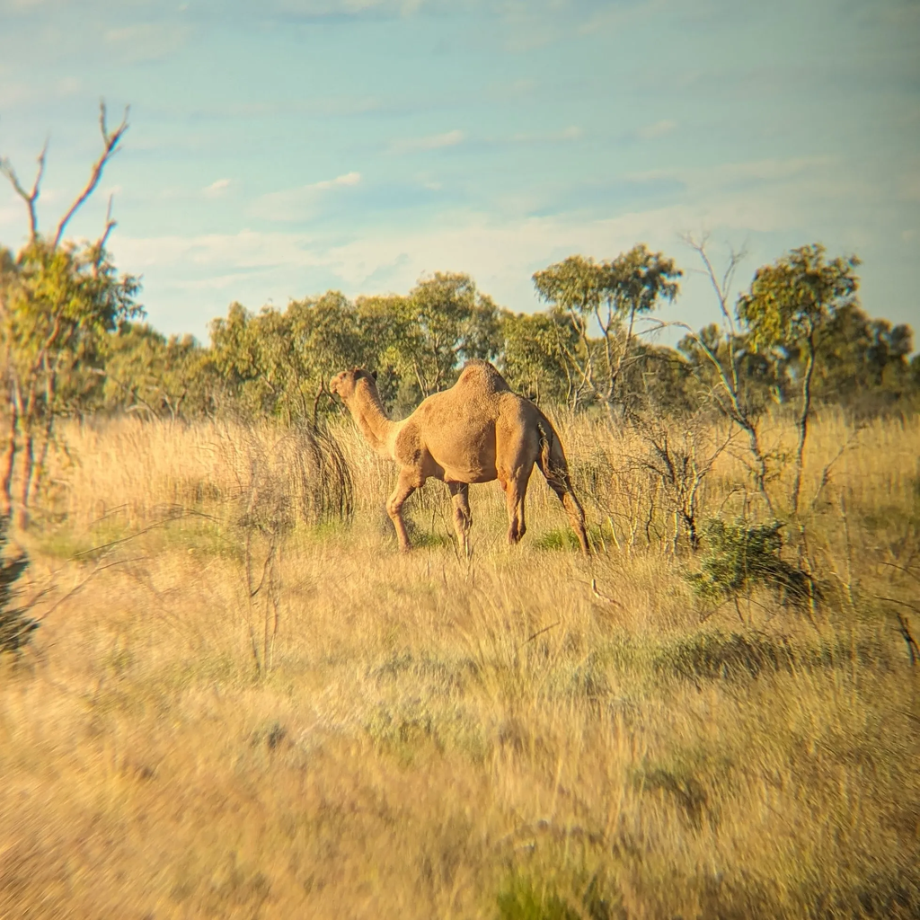

##### 📄 Balancing trade-offs when animal dispersal simultaneously moves beneficial and harmful cargo ✨ AI title

Shared by **Andrew Abraham** [@andrewabraham.bsky.social](https://bsky.app/profile/andrewabraham.bsky.social) · 2026-05-27 · 💚 8 likes on Bluesky

```
<div class='tag-row'><span class='tag tag-ecosystem-services'>ecosystem-services</span><span class='tag tag-disease'>disease</span></div>
{% raw %}Doubled-edged Dispersal! In the Anthropocene, animals disperse a lot of things. From seeds and nutrients, to pathogens and invasives. Our new paper discusses the need to balance trade-offs when both desirable and undesirable functions occur simultaneously{% endraw %}
```

**link:** https://www.sciencedirect.com/science/article/pii/S0169534726001011?dgcid=author  
[View Original Post on Bluesky](https://bsky.app/profile/did:plc:h7n2ktda22q5m7cdz4cnos2r/post/3mmumy7zj2s2w)↑ Up

[output not shown]

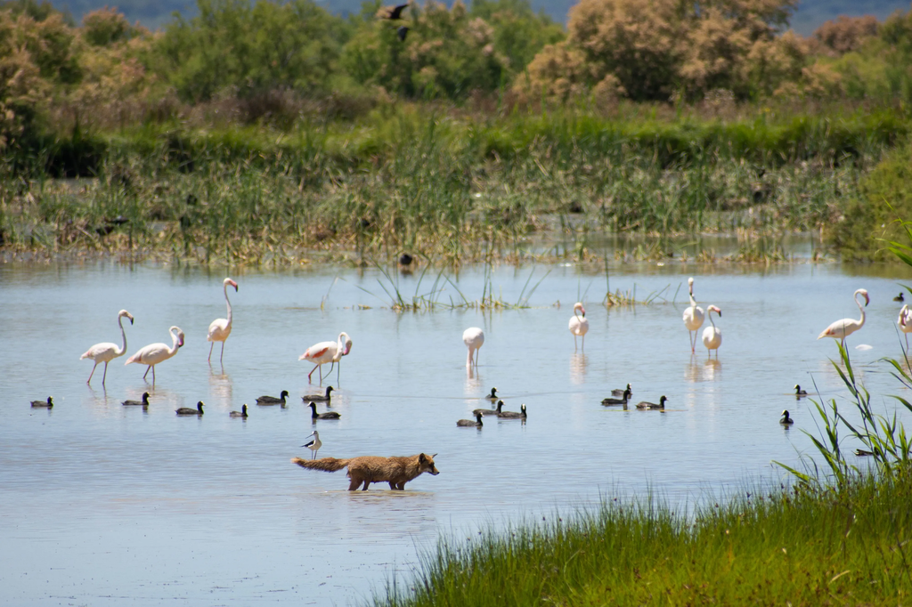

##### 📄 Plant species loss in rich meadows does not weaken competition or free up resources ✨ AI title

Shared by **Jules Segrestin** [@jsegrestin.bsky.social](https://bsky.app/profile/jsegrestin.bsky.social) · 2026-05-27 · 💚 8 likes on Bluesky

```
<div class='tag-row'><span class='tag tag-traits'>traits</span></div>
{% raw %}Using phytometers, we show that plant species loss in a species-rich meadow does not weaken competition or free up resources, highlighting the complexity of biodiversity–competition relationships. 🔗🔓 Paper in @journalofecology.bsky.social led by Eva Janíková 🌍🌐📏{% endraw %}
```

**link:** https://doi.org/10.1111/1365-2745.70335  
[View Original Post on Bluesky](https://bsky.app/profile/did:plc:ek66hq3gwb4afzhzwiflr5sv/post/3mmtsemv7wk27)↑ Up

[output not shown]

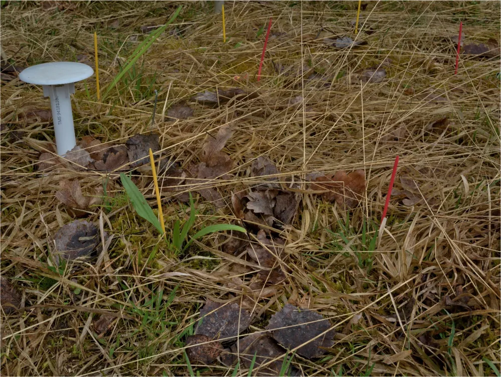

Shared by **Nicolas Mouquet** [@nmouquet.bsky.social](https://bsky.app/profile/nmouquet.bsky.social) · 2026-05-27 · 💚 12 likes on Bluesky

```
<div class='tag-row'><span class='tag tag-macroecology'>macroecology</span></div>
{% raw %}Happy to release v2 of the @global-ecology.bsky.social Digest 🌐✨💚 The new version includes: • weekly wrap-ups • improved visualisation • archives A curated feed into biodiversity & global change research for anyone on to share online here 👉 🧪🌍🦤🦑🪴🍁{% endraw %}
```

**link:** https://globalecologybs.github.io/feeddigest.github.io/archives/digest-2026-22/  
[View Original Post on Bluesky](https://bsky.app/profile/did:plc:ppsghcl5bbpgjcljnhra353s/post/3mmtrul6dyc2q)↑ Up

[output not shown]

[figure not shown]

##### 📄 Coral tissue oxygen transport system collapses under heat stress ✨ AI title

Shared by **César O. Pacherres** [@pacherres-co.bsky.social](https://bsky.app/profile/pacherres-co.bsky.social) · 2026-05-27 · 💚 23 likes on Bluesky

```
<div class='tag-row'><span class='tag tag-coral-reef'>coral-reef</span><span class='tag tag-climate'>climate</span><span class='tag tag-traits'>traits</span></div>
{% raw %}Coral reefs are increasingly threaten by marine heatwaves, but what pushes corals past their breaking point? New in @ScienceAdvances @science.org: we found that corals can lose the microscopic system that helps move oxygen around their tissues during heat stress 🪸{% endraw %}
```

**link:** https://doi.org/10.1126/sciadv.aeg0950  
[View Original Post on Bluesky](https://bsky.app/profile/did:plc:mjmrpiqqnxm5peg4c2gnkhl5/post/3mmtoums3ps23)↑ Up

[output not shown]

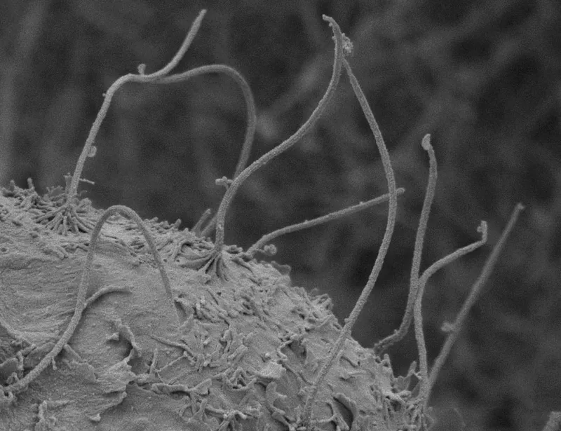

##### 📄 New R package Spatial+: addressing spatial confounding in ecological models ✨ AI title

Shared by **Francisco Rodriguez-Sanchez** [@frodsan.bsky.social](https://bsky.app/profile/frodsan.bsky.social) · 2026-05-27 · 💚 14 likes on Bluesky

```
<div class='tag-row'><span class='tag tag-methods'>methods</span><span class='tag tag-macroecology'>macroecology</span></div>
{% raw %}Spatial+: a relatively easy way to address spatial confounding Comparison with other methods: statistics rspatial{% endraw %}
```

**link:** https://doi.org/10.1111/biom.13656  
[View Original Post on Bluesky](https://bsky.app/profile/did:plc:c4uwzyiy4la35kq35rsft35z/post/3mmtl24vqtc2v)↑ Up

[output not shown]

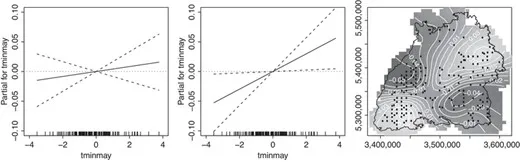